# Setup

```python
# imports
from dm_control import suite
from dm_control import viewer
from dm_env import StepType
import numpy as np
import copy
import matplotlib.pyplot as plt
import statistics
import time
```

# Discovering the module

Create the environement and test the visualization with a very bad policy.

```python
# Create the environment
env = suite.load(domain_name='cartpole', task_name='swingup')
action_spec = env.action_spec()

# Define a uniform random policy.
def random_policy(time_step):
  #del time_step  # Unused.
  print(time_step.observation)
  return np.random.uniform(low=action_spec.minimum,
                           high=action_spec.maximum,
                           size=action_spec.shape)

def move_right_policy(time_step):
  cart_pos = time_step.observation['position'][0]
  if cart_pos < 1:
    action = np.array([1.0])
  else:
    action = np.array([0.0])
  return action


# Launch the viewer application.
viewer.launch(env, policy=move_right_policy)
```

## Observationspace

```python
# Observationspace
env = suite.load(domain_name='cartpole', task_name='balance')

env.observation_spec()
```

```
OrderedDict([('position',
              Array(shape=(3,), dtype=dtype('float64'), name='position')),
             ('velocity',
              Array(shape=(2,), dtype=dtype('float64'), name='velocity'))])
```

```python
# Timestep
action = 0
print('action = ', action)
env.step(action)
```

```
action =  0
```

```
TimeStep(step_type=<StepType.FIRST: 0>, reward=None, discount=None, observation=OrderedDict([('position', array([ 0.04127947,  0.99996644, -0.00819285])), ('velocity', array([ 0.01127069, -0.00110715]))]))
```

`env.step(action)` returns a timestep containing 4 variables:

- Type of timestep (first, mid, last)
- reward (between 1 and 0)
- discount
- observation containing of 2 parts (position and velocity)

```python
timestep, reward, discount, observation = env.step(action)
observation
```

```
OrderedDict([('position', array([ 0.04139246,  0.9999663 , -0.00821018])),
             ('velocity', array([ 0.0113275 , -0.00235811]))])
```

```python
time_step = env.step(0)
pos = time_step.observation['position']
vel = time_step.observation['velocity']
physics = env.physics.get_state()
print('position', pos)
print('velocity', vel)
print('physics', physics)
print(np.arctan2(time_step.observation['position'][2],time_step.observation['position'][1]))
# arctan2 calculates the angle out of the sin and cos of the angle.
```

```
position [ 0.04150602  0.99996605 -0.00824003]
velocity [ 0.01138447 -0.00361266]
physics [ 0.04150602 -0.00824012  0.01138447 -0.00361266]
-0.008240119006751031
```

```python
print('theta = ', physics[1])
print('sin of theta = ', np.sin(physics[1]))
print('cos of theta = ', np.cos(physics[1]))
```

```
theta =  -0.008240119006751031
sin of theta =  -0.008240025756990085
cos of theta =  0.9999660504114748
```

The observation consist of a position dict with

- Position of the cart
- Cosin of the pole angle
- Sin of the pole angle

and a velcity dict with

- $\dot{x}$: speed of the cart
- $\dot{\theta}$: angular velocity of the pole

The output of `env.physics.get_state()` is

- x: position of the cart
- $\theta$: angle of the pole, 0 in the upright position
- $\dot{x}$: speed of the cart
- $\dot{\theta}$: angular velocity of the pole

## Actionspace

```python
# Actionspace
action_space = env.action_spec()
action_space
```

```
BoundedArray(shape=(1,), dtype=dtype('float64'), name=None, minimum=[-1.], maximum=[1.])
```

The action consists of a force applied on the cart. The action needs to be between -1 and 1 and is continuous. As noted in the `cartpole.xml` file, the gear of the actuator is 10. This means that force applied is the $action * 10$. Thus the force applied is between -10 and 10N.

# Rollout

In predictive sampling, different set of actions are sampled and the best is picked.

## Actionsampling

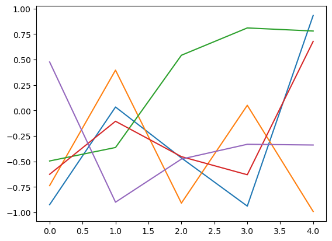

```
array([[-0.92416305, -0.73729562, -0.49516753, -0.62592706,  0.4767893 ],
       [ 0.03439686,  0.39634435, -0.36300105, -0.10539812, -0.8998223 ],
       [-0.46547556, -0.90891087,  0.54258721, -0.45264417, -0.47661524],
       [-0.93825801,  0.05128665,  0.81065161, -0.63032347, -0.33144592],
       [ 0.93324674, -0.99139928,  0.78036592,  0.67907584, -0.33854382]])
```

```python
# Random sampling of actions
horizon = 5
num_samples = 5

u = np.random.uniform(action_space.minimum, action_space.maximum, (num_samples, horizon))
plt.plot(u)
plt.show()
u
```

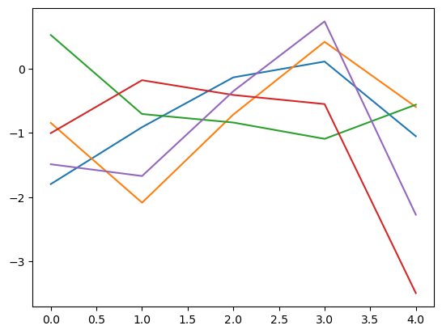

```
array([[-1.79637836, -0.84373626,  0.52595251, -1.00248271, -1.48766344],
       [-0.90953781, -2.0862439 , -0.70460586, -0.17802908, -1.67060582],
       [-0.13422806, -0.71282679, -0.83754382, -0.40840098, -0.34904757],
       [ 0.11271058,  0.42006304, -1.09154718, -0.54971743,  0.73798605],
       [-1.05108972, -0.59489201, -0.55941161, -3.49572681, -2.27364407]])
```

```python
# Gaussian sampling
u = np.random.normal(action_space.minimum, action_space.maximum, (num_samples, horizon))
plt.plot(u)
plt.show()
u
```

### Hotstart

Hotstart is defiend as using the best solution of the last iteration as the starting point of the next iteration and thus improving the solution.

As one as done one step, the first step is cut and a the last step is copied (one could also a 0 as last value as this is most probable) to maintain the length of the horizon.

```python
arr = [0.1,0.5,0.5]
# Remove the first element
arr = np.delete(arr, 0)

# Duplicate the last element
last_element = arr[-1]
arr = np.append(arr, last_element)
arr
```

```
array([0.5, 0.5, 0.5])
```

```python
# Gaussian sampling arroung a chosen mean
mean = np.array([0, 0,])
cov = np.array([[1, 0], [0, 1]])
x = np.random.multivariate_normal(mean, cov, 5)
x
```

```
array([[-2.00714654,  1.99187599],
       [ 0.6115983 , -0.20842149],
       [-1.64536301, -2.07581725],
       [-0.0837603 ,  0.06050366],
       [-1.46517702,  0.43631293]])
```

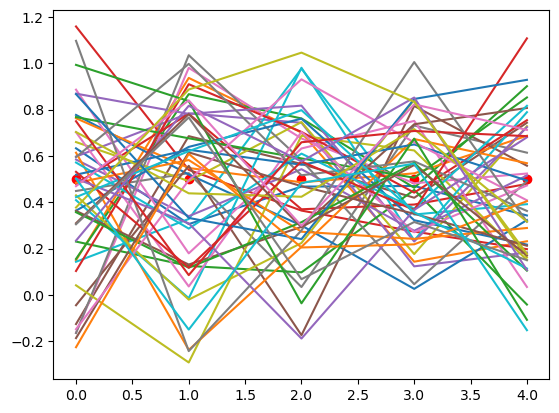

```python
# Gaussian distribution around u_start (red dots)
u_start = [0.5,0.5,0.5,0.5,0.5]
cov = np.eye(5)*0.1
u_new = np.random.multivariate_normal(u_start, cov, 50).T
plt.plot(u_start, 'ro')
plt.plot(u_new)
plt.show()
```

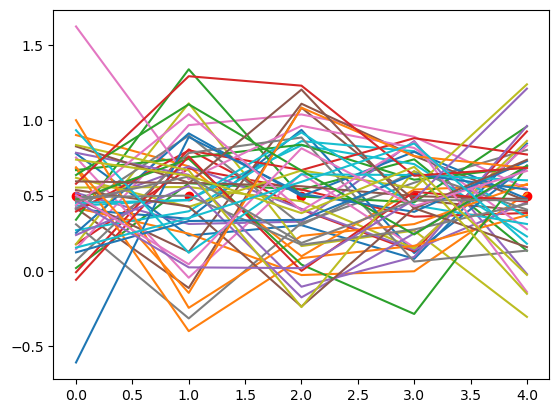

```python
# introduce w_cov the adjust the size of the spread of the Gauss sampling
w_cov = 0.1
u_start = [0.5,0.5,0.5,0.5,0.5]
cov = np.eye(5) * w_cov
u_new = np.random.multivariate_normal(u_start, cov, 50).T
plt.plot(u_start, 'ro')
plt.plot(u_new)
plt.show()
```

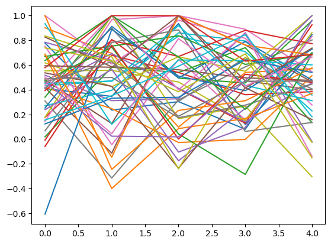

```python
# cut all values above 1 and below -1 as this are max and min
u_new = np.clip(u_new,-1,1)
plt.plot(u_new)
plt.show()
```

```python
# include u_start in the new u
u_start = np.array([0.5,0.5,0.5,0.5,0.5])
cov = np.eye(5) * w_cov
u_new = np.random.multivariate_normal(u_start, cov, 5).T
u_new = np.concatenate((u_start[np.newaxis, :], u_new), axis=0)
u_new
```

```
array([[ 0.5       ,  0.5       ,  0.5       ,  0.5       ,  0.5       ],
       [ 0.66957714,  0.54898528,  0.78146212,  0.54235061,  0.47712671],
       [ 0.55242377,  0.11585624,  0.86361465, -0.19082862,  0.65542317],
       [ 0.90410952,  0.51834115,  0.17908651,  0.60670984,  0.62853966],
       [ 0.87469715, -0.48668207,  0.8268018 ,  0.55442413,  0.58355604],
       [-0.16554715,  0.71832437,  0.86618174,  0.68264821,  0.25303522]])
```

# Model

## Analytical Solution

The Cart-Pole problem is a classic control theory problem used to test reinforcement learning algorithms. It involves balancing a pole, hinged to a cart, by moving the cart horizontally. The objective is to keep the pole upright for as long as possible without letting it fall or the cart moving out of the defined boundaries.

To describe the Cart-Pole problem mathematically, we need to define the state variables, control input, and the equations of motion.

### State variables

The state of the system at any given time can be represented by a 4-dimensional vector:

$s(t) = [x(t), \dot{x}(t), \theta(t), \dot{\theta}(t)]$

where:

- $x(t)$ position of the cart at time t
- $\dot{x}(t)$ velocity of the cart at time t
- $\theta(t)$ angle of the pole with the vertical axis at time t
- $\dot{\theta}(t)$ angular velocity of the pole at time t

### Control input

The control input is the horizontal force applied to the cart using an actuator:

$u(t) = F$

where F is the force applied to the cart, and it can be positive (to the right) or negative (to the left).

### Equations

To describe the CartPole problem mathematically, we can use the equations of motion derived from the system's dynamics. The system can be modeled as a two-link system, with the cart and the pole, and the dynamics are governed by Newton's laws of motion.

Let's define the following variables:

- $x$ position of the cart (along the horizontal axis)
- $\theta$ angle of the pole with respect to the vertical (upright) position
- $m_c$ mass of the cart
- $m_p$ mass of the pole
- $l$ length of the pole (from the pivot point to the center of mass of the pole)
- $F$ force applied on the cart
- $g$: acceleration due to gravity

The equations of motion can be derived using Newton's second law (F = ma) and Euler-Lagrange equations.

Acceleration of the cart ($\ddot{x}$):

$\ddot{x} = \frac{F + m_p \sin(\theta) (l \dot{\theta}^2 + g \cos(\theta))}{m_c + m_p \sin^2(\theta)}$

Angular acceleration of the pole ($\ddot{\theta}$):

$\ddot{\theta} = - \frac{F \cos(\theta) + m_p l \dot{\theta}^2 \sin(\theta) \cos(\theta) + (m_c + m_p) g \sin(\theta)}{l (m_c + m_p \sin^2(\theta))}$

### Discrete time

Update the position and velocity of the cart:

$x[t+1] = x[t] + \dot{x}[t] * \Delta t$

$\dot{x}[t+1] = \dot{x}[t] + \ddot{x}[t] * \Delta t$

Update the angle and angular velocity of the pole:

$\theta[t+1] = \theta[t] + \dot{\theta}[t] * \Delta t$

$\dot{\theta}[t+1] = \dot{\theta}[t] + \ddot{\theta}[t] * \Delta t$

```python
# values from cartpole.xml
dt = 0.01
g = 9.81
m_c = 1
m_p = 0.1
l = 0.5
d_c = 5e-4
d_p = 2e-6
gear = 10 # from input to force in Newton
```

```python
#test different dynamical equations
env.reset()
state = env.physics.get_state()
x, x_dot, theta, theta_dot = state
F = 1

sin_theta = np.sin(theta)
cos_theta = np.cos(theta)

# equation from ChatGPT:
denom = m_c + m_p * sin_theta**2
x_double_dot = (F + m_p * sin_theta * (l * theta_dot**2 + g * cos_theta) - d_c * x_dot) / denom
theta_double_dot = (-(F * cos_theta + m_p * l * theta_dot**2 * cos_theta * sin_theta + (m_c + m_p) * g * sin_theta) - d_p * theta_dot) / (l * denom)

# equation from google:
det = m_p * l * cos_theta**2 - l * (m_c + m_p)
x_double_dot = (-m_p * l * g * sin_theta * cos_theta - l * (F + m_p * l * theta_dot**2 * sin_theta)) / det
theta_double_dot = ((m_c + m_p) * g * sin_theta + cos_theta * (F + m_p * l * theta_dot**2 * sin_theta)) / det

#sigmunds equations
pole_mpl = m_p * l
x_double_dot = (-2 * pole_mpl * (theta_dot**2) * sin_theta + 3 * m_p * g * sin_theta * cos_theta + 4 * F - 4 * d_c * x_dot) / (4 * (m_c + m_p) - 3 * m_p * cos_theta**2)
theta_double_dot = (-3 * pole_mpl * (theta_dot**2) * sin_theta * cos_theta + 6 * (m_c + m_p) * g * sin_theta + 6 * (F - d_p * x_dot) * cos_theta) / (4 * l * (m_c + m_p) - 3 * pole_mpl * cos_theta**2)


# wrong equations from https://coneural.org/florian/papers/05_cart_pole.pdf
theta_double_dot = (g * sin_theta + cos_theta * (-F - m_p * l * theta_dot**2 * sin_theta + d_c * np.sign(x_dot))/(m_c + m_p) - (d_p * theta_dot)/(m_p * l)) / (l * (4/3 - (m_p * cos_theta**2)/(m_c + m_p)))
x_double_dot = (F + m_p * l * (theta_dot**2 * sin_theta - theta_double_dot * cos_theta) - d_c * np.sign(x_dot))/(m_c + m_p)
# these equations works fine

# correct equations from https://coneural.org/florian/papers/05_cart_pole.pdf
Nc = (m_c + m_p) * g - m_p * l * (theta_double_dot * sin_theta + theta_dot**2 * cos_theta)
theta_double_dot = (g * sin_theta + cos_theta * (-F - m_p * l * theta_dot**2 * (sin_theta + d_c * np.sign(Nc * x_dot) * cos_theta)/(m_c + m_p) + d_c * g * np.sign(Nc * x_dot)) - (d_p * theta_dot) / (m_p * l)) / (l * (4/3 - (m_p * cos_theta)/(m_c + m_p) * (cos_theta - d_c * np.sign(Nc * x_dot))))
x_double_dot = (F + m_p * l * (theta_dot**2 * sin_theta - theta_double_dot * cos_theta) - d_c * Nc * np.sign(Nc * x_dot))/(m_c + m_p)
# this performs not better!
```

```python
# insert of the dynaical equations
def cartpole_derivatives(state, F, m_c, m_p, l, g): # F * 10 to
    x, x_dot, theta, theta_dot = state

    sin_theta = np.sin(theta)
    cos_theta = np.cos(theta)

    theta_double_dot = (g * sin_theta + cos_theta * (-F - m_p * l * theta_dot**2 * sin_theta + d_c * np.sign(x_dot))/(m_c + m_p) - (d_p * theta_dot)/(m_p * l)) / (l * (4/3 - (m_p * cos_theta**2)/(m_c + m_p)))
    x_double_dot = (F + m_p * l * (theta_dot**2 * sin_theta - theta_double_dot * cos_theta) - d_c * np.sign(x_dot))/(m_c + m_p)

    return np.array([x_dot, x_double_dot, theta_dot, theta_double_dot])

def euler_step(state, F, m_c, m_p, l, g, dt):
    derivatives = cartpole_derivatives(state, F*gear, m_c, m_p, l, g) # gear 10 the adjust the force to Newton
    new_state = state + dt * derivatives
    return new_state

def rk4_step(state, F, m_c, m_p, l, g, dt):
    F = F * gear # gear 10 the adjust the force to Newton
    k1 = cartpole_derivatives(state, F, m_c, m_p, l, g )
    k2 = cartpole_derivatives(state + 0.5 * dt * k1, F, m_c, m_p, l, g)
    k3 = cartpole_derivatives(state + 0.5 * dt * k2, F, m_c, m_p, l, g)
    k4 = cartpole_derivatives(state + dt * k3, F, m_c, m_p, l, g)

    new_state = state + (dt / 6) * (k1 + 2 * k2 + 2 * k3 + k4)
    return new_state
```

### Comparison of model and environement

```
startstate [-1.09924199e-02 -6.77947693e-04  3.13959120e+00  1.34667147e-02]

env  [-0.0106434   0.07048081  3.14024398  0.11707202]
euler  [-0.0109992   0.07065302  3.13972587  0.12075746]
rk4  [-0.01064258  0.07064313  3.14026217  0.12070643]

env  [-0.0239599  -0.0130059   3.10847409 -0.02263912]
euler  [-0.02400899 -0.01334009  3.10651487 -0.0305555 ]
rk4  [-0.02406158 -0.01297697  3.10663853 -0.02217406]

env  [ 0.13085881  0.20844939  3.27052413 -0.17697868]
euler  [ 0.13008545  0.20803917  3.27827311 -0.18346272]
rk4  [ 0.13093077  0.20740684  3.27330234 -0.19690321]

env  [ 0.11868619  0.05550335  2.93589375 -0.25507008]
euler  [ 0.1174379   0.05387018  2.91811216 -0.29012359]
rk4  [ 0.11805905  0.0561671   2.92487368 -0.23747537]

env  [ 0.09613973 -0.06631476  3.10697622  0.82797157]
euler  [ 0.09672957 -0.060422    3.11230374  0.95773557]
rk4  [ 0.09669009 -0.06414084  3.12336037  0.87674272]

env  [ 0.18620904  0.12489482  3.4853262  -0.22490066]
euler  [ 0.18702818  0.12078064  3.52456433 -0.32206239]
rk4  [ 0.1860639   0.11972466  3.48780817 -0.34138323]
```

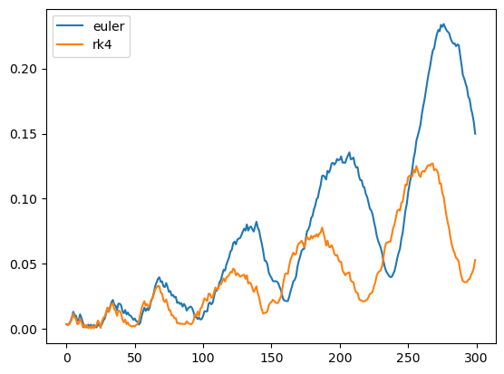

```python
# compare dynamical equations and RK with euler
# the different dynamical equations need to be copy-pasted into the cartpole_derivatives function
F = -0.1
env.reset()

real_state = env.physics.get_state()
start_state = np.array([real_state[0],real_state[2],real_state[1],real_state[3]]) #reorder to same order as cartpole derivatives
euler_state = start_state
rk4_state = start_state

euler_error = []
rk4_error = []

print('startstate', start_state)
print()
for i in range(300):
    F = np.random.uniform(low=action_spec.minimum, high=action_spec.maximum, size=action_spec.shape)[0]
    env.step(F)
    env_state = env.physics.get_state()
    env_state = np.array([env_state[0],env_state[2],env_state[1],env_state[3]])
    euler_state = euler_step(euler_state, F, m_c, m_p, l, g, dt)
    rk4_state = rk4_step(rk4_state, F, m_c, m_p, l, g, dt)
    if i%50 == 0: # print every 10th timestep
        print('env ', env_state)
        print('euler ', euler_state)
        print('rk4 ', rk4_state)
        print()
    euler_error.append(np.linalg.norm(env_state - euler_state))
    rk4_error.append(np.linalg.norm(env_state - rk4_state))

plt.plot(euler_error, label='euler')
plt.plot(rk4_error, label='rk4')
plt.legend()
```

# Rollout

```python
# parameters
# Define the predictive sampling controller parameters
horizon = 50
num_samples = 10

# Define the weights
w_angle = 1
w_center = 0.5
w_vel = 0
w_cov = 0.1

# initalize an optimal action
opt_u = np.zeros(horizon)
cov = np.eye(horizon) * w_cov

#constraints
x_min = -1.8
x_max = 1.8

constraint_penalty = 1e8
soft_constraint_weight = 1e5
soft_constraint_margin = 0.1
```

```python
def rollout(u, state):
    cost = 0

    for j in range(horizon):
        state = euler_step(state, u[j], m_c, m_p, l, g, dt) # interate through the simulation

        cart_position_cost = 0
        if state[0] < x_min or state[0] > x_max:
            cart_position_cost = constraint_penalty
        else:
            cart_position_margin = min(state[0] - x_min, x_max - state[0])
            if cart_position_margin < soft_constraint_margin:
                cart_position_cost = soft_constraint_weight * (soft_constraint_margin - cart_position_margin)

        cost += 1**j * (w_angle * (1 - np.cos(state[2])) + w_center * (state[0])**2 + w_vel * (state[3])**2 + cart_position_cost)  # sum the cost
    return cost
```

```python
# Policy
def predictiv_sampling_policy(time_step):
  # sample control inputs
  # Remove the first element
  global opt_u
  opt_u = np.delete(opt_u, 0)
  opt_u = np.append(opt_u, opt_u[-1]) # Duplicate the last element

  u = np.random.multivariate_normal(opt_u, cov, num_samples-1)
  u = np.concatenate((opt_u[np.newaxis, :], u), axis=0) # add opt_u to the new samples
  u = np.clip(u,-1,1)

  # save the state of the environment and create a copy to simulate in
  real_state = env.physics.get_state()[[0, 2, 1, 3]] # adjust the order to x, xdot, theta, thetadot

  # calculate rollouts and cost
  cost = [rollout(u[i], real_state) for i in range(num_samples)]

  # Choose the control input with the lowest cost
  best_index = np.argmin(cost)
  opt_u = u[best_index]

  return opt_u[0]
```

# Simulation

```python
env = suite.load(domain_name='cartpole', task_name='swingup')
# Launch the viewer application.
viewer.launch(env, policy=predictiv_sampling_policy)
```

```python
# check total reward

timestep, reward, discount, observation = env.reset()
total_reward = 0
while timestep is not(StepType.LAST):
    action = predictiv_sampling_policy(time_step)
    timestep, reward, discount, observation = env.step(action)
    total_reward += reward

print(total_reward)
```

```
474.22528720368956
```

```python
def rollout_theta(u, state):
    cost = 0
    theta = []

    for j in range(horizon):
        state = euler_step(state, u[j], m_c, m_p, l, g, dt) # interate through the simulation

        cart_position_cost = 0
        if state[0] < x_min or state[0] > x_max:
            cart_position_cost = constraint_penalty
        else:
            cart_position_margin = min(state[0] - x_min, x_max - state[0])
            if cart_position_margin < soft_constraint_margin:
                cart_position_cost = soft_constraint_weight * (soft_constraint_margin - cart_position_margin)

        cost += 1**j * (w_angle * (1 - np.cos(state[2])) + w_center * (state[0])**2 + w_vel * (state[3])**2 + cart_position_cost)  # sum the cost
        theta.append(state[2])
    return cost, theta
```

## Check the improvement of theta when refining u

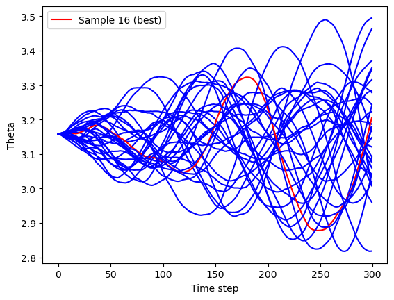

```python
# development of theta, first sampling
horizon = 300
num_samples = 30
w_cov = 0.1
cov = np.eye(horizon) * w_cov

timestep, reward, discount, observation = env.reset()

opt_u = np.zeros(horizon)
#opt_u = np.ones(horizon)*-1

u = np.random.multivariate_normal(opt_u, cov, num_samples)
u = np.clip(u,-1,1)

# save the state of the environment and create a copy to simulate in
real_state = env.physics.get_state()[[0, 2, 1, 3]] # adjust the order to x, xdot, theta, thetadot

# calculate rollouts and cost
temp = [rollout_theta(u[i], real_state) for i in range(num_samples)]
cost = [t[0] for t in temp]
theta = [t[1] for t in temp]

# Choose the control input with the lowest cost
best_index = np.argmin(cost)
opt_u = u[best_index]
theta_collection = [theta[best_index]]

# Plot the angles
best_color = 'red'
non_best_color = 'blue'

for i, angles in enumerate(theta):
    if i == best_index:
        plt.plot(angles, color=best_color, linestyle='-', label=f'Sample {i} (best)')
    else:
        plt.plot(angles, color=non_best_color, linestyle='-')

plt.xlabel('Time step')
plt.ylabel('Theta')
plt.legend()
plt.show()
```

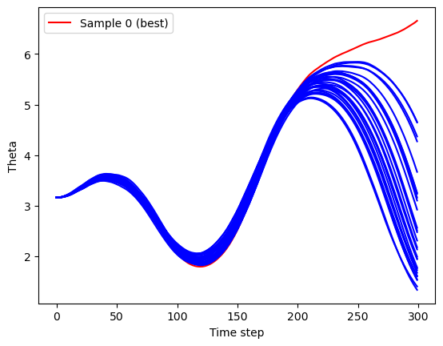

```python
# improve to standing upright after X iterations
for i in range(300):
    u = np.random.multivariate_normal(opt_u, cov, num_samples-1)
    u = np.concatenate((opt_u[np.newaxis, :], u), axis=0) # add opt_u to the new samples
    u = np.clip(u,-1,1)

    # save the state of the environment and create a copy to simulate in
    real_state = env.physics.get_state()[[0, 2, 1, 3]] # adjust the order to x, xdot, theta, thetadot

    # calculate rollouts and cost
    temp = [rollout_theta(u[i], real_state) for i in range(num_samples)]
    cost = [t[0] for t in temp]
    theta = [t[1] for t in temp]

    # Choose the control input with the lowest cost
    best_index = np.argmin(cost)
    opt_u = u[best_index]
    theta_collection.append(theta[best_index])

# Plot the angles
best_color = 'red'
non_best_color = 'blue'

for i, angles in enumerate(theta):
    if i == best_index:
        plt.plot(angles, color=best_color, linestyle='-', label=f'Sample {i} (best)')
    else:
        plt.plot(angles, color=non_best_color, linestyle='-')

plt.xlabel('Time step')
plt.ylabel('Theta')
plt.legend()
plt.show()
```

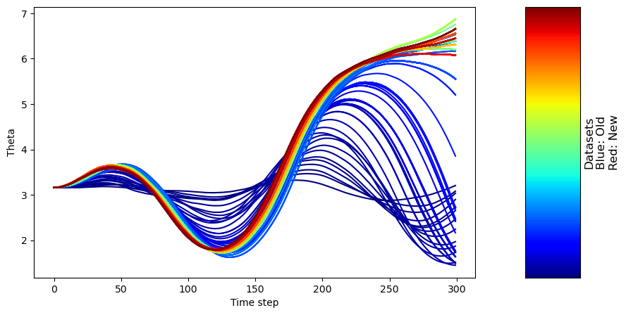

```python
import numpy as np
from matplotlib import cm
from matplotlib.colors import Normalize
import matplotlib.pyplot as plt

num_datasets = len(theta_collection)
# Choose a colormap
colormap = cm.jet

# Normalize the dataset indices to the range of 0-1 for the colormap
norm = Normalize(0, num_datasets - 1)

# Create a meshgrid with y values corresponding to dataset indices
Y = np.array([[i] * 2 for i in range(num_datasets)])
X = np.array([[0, 1]])

# Plot each dataset with a slightly different color
fig, (ax1, ax2) = plt.subplots(1, 2, figsize=(10, 5), gridspec_kw={'width_ratios': [8, 1]})

for i, data in enumerate(theta_collection):
    ax1.plot(data, color=colormap(norm(i)))

# Plot the colorbar
colorbar = ax2.pcolormesh(X, Y, Y, cmap=colormap, shading='auto')

# Set colorbar limits and orientation
colorbar.set_clim(0, num_datasets - 1)
ax2.set_xticks([])
ax2.set_yticks([])
ax2.set_ylabel('Datasets\nBlue: Old\nRed: New', fontsize=12)
ax2.yaxis.set_label_position("right")

ax1.set_xlabel('Time step')
ax1.set_ylabel('Theta')
plt.show()
```

a clear improve of solution of the recent and thus further developed solutions can be seen.

## Multiprocessing

Using threads

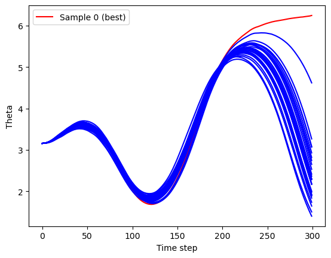

```python
# multiprocessing
import multiprocessing.dummy as mp

for i in range(300):
    u = np.random.multivariate_normal(opt_u, cov, num_samples-1)
    u = np.concatenate((opt_u[np.newaxis, :], u), axis=0) # add opt_u to the new samples
    u = np.clip(u,-1,1)

    # save the state of the environment and create a copy to simulate in
    real_state = env.physics.get_state()[[0, 2, 1, 3]] # adjust the order to x, xdot, theta, thetadot

    # calculate rollouts and cost
    with mp.Pool() as pool:
        temp = pool.starmap(rollout_theta, [(u_val, real_state) for u_val in u])

    cost = [t[0] for t in temp]
    theta = [t[1] for t in temp]

    # Choose the control input with the lowest cost
    best_index = np.argmin(cost)
    opt_u = u[best_index]
    theta_collection.append(theta[best_index])

# Plot the angles
best_color = 'red'
non_best_color = 'blue'

for i, angles in enumerate(theta):
    if i == best_index:
        plt.plot(angles, color=best_color, linestyle='-', label=f'Sample {i} (best)')
    else:
        plt.plot(angles, color=non_best_color, linestyle='-')

plt.xlabel('Time step')
plt.ylabel('Theta')
plt.legend()
plt.show()
```

Multiprocessing using threads does not show a significant improvement. The reason you're not seeing a significant speedup could be due to the Global Interpreter Lock (GIL) in Python, which prevents multiple native threads from executing Python bytecodes concurrently. Even though you're using multiple threads, they are not able to run simultaneously due to the GIL, and therefore the performance improvement is limited.

```python
import concurrent.futures
# improve to standing upright after X iterations
for i in range(300):

    break # this can be removed do check the code below but is here to prevent the code from running


    u = np.random.multivariate_normal(opt_u, cov, num_samples-1)
    u = np.concatenate((opt_u[np.newaxis, :], u), axis=0) # add opt_u to the new samples
    u = np.clip(u,-1,1)

    # save the state of the environment and create a copy to simulate in
    real_state = np.array(env.physics.get_state()[[0, 2, 1, 3]]) # adjust the order to x, xdot, theta, thetadot

    # calculate rollouts and cost
    with concurrent.futures.ProcessPoolExecutor() as executor:
        temp = list(executor.map(lambda u_val: rollout_theta(u_val, real_state), u))

    cost = [t[0] for t in temp]
    theta = [t[1] for t in temp]

    # Choose the control input with the lowest cost
    best_index = np.argmin(cost)
    opt_u = u[best_index]
    theta_collection.append(theta[best_index])

'''# Plot the angles
best_color = 'red'
non_best_color = 'blue'

for i, angles in enumerate(theta):
    if i == best_index:
        plt.plot(angles, color=best_color, linestyle='-', label=f'Sample {i} (best)')
    else:
        plt.plot(angles, color=non_best_color, linestyle='-')

plt.xlabel('Time step')
plt.ylabel('Theta')
plt.legend()'''
```

[output not shown]

## Finetuning of the hyperparameters

```python
# 1. Define the hyperparameter search space
w_cov_values = np.logspace(-3, 1, 5)
w_center_values = np.logspace(-4, 0, 5)
w_vel_values = np.logspace(-5, 0, 6)
w_fast_rewards_values = np.linspace(1.05, 0.9, 4)
num_samples_values = np.arange(10, 50, 10)
horizon_values = np.arange(20, 170, 30)

# Store the search space in a list of lists
search_space = [w_cov_values, w_center_values, w_vel_values, w_fast_rewards_values, num_samples_values, horizon_values]
w_cov_values
```

```
array([1.e-03, 1.e-02, 1.e-01, 1.e+00, 1.e+01])
```

```python
import itertools

# 2. Iterate through all possible combinations of hyperparameters
best_metric = 0 # Initialize the best metric value (assuming higher is better)
best_hyperparameters = None

for hyperparameters in itertools.product(*search_space):
    break # this can be removed do check the code below but is here to prevent the code from running, this is to illustrate how the parameters were
    # fintuned. the priciple uf superposition is used to find the best hyperparameters
    w_cov, w_center = hyperparameters

    # 3. Run the simulation with the current set of hyperparameters
    # ... (your simulation code with the updated hyperparameters)
    opt_u = np.zeros(horizon)
    cov = np.eye(horizon) * w_cov


    def rollout(u, state):
        cost = 0

        for j in range(horizon):
            state = euler_step(state, u[j], m_c, m_p, l, g, dt) # interate through the simulation

            cart_position_cost = 0
            if state[0] < x_min or state[0] > x_max:
                cart_position_cost = constraint_penalty
            else:
                cart_position_margin = min(state[0] - x_min, x_max - state[0])
                if cart_position_margin < soft_constraint_margin:
                    cart_position_cost = soft_constraint_weight * (soft_constraint_margin - cart_position_margin)

            cost += w_fast_rewards**j * (w_angle * (1 - np.cos(state[2])) + w_center * (state[0])**2 + w_vel * (state[3])**2 + cart_position_cost)  # sum the cost
        return cost
    def predictiv_sampling_policy(time_step):
        # sample control inputs
        # Remove the first element
        global opt_u
        opt_u = np.delete(opt_u, 0)
        opt_u = np.append(opt_u, opt_u[-1]) # Duplicate the last element

        u = np.random.multivariate_normal(opt_u, cov, num_samples-1)
        u = np.concatenate((opt_u[np.newaxis, :], u), axis=0) # add opt_u to the new samples
        u = np.clip(u,-1,1)

        # save the state of the environment and create a copy to simulate in
        real_state = env.physics.get_state()[[0, 2, 1, 3]] # adjust the order to x, xdot, theta, thetadot

        # calculate rollouts and cost
        cost = [rollout(u[i], real_state) for i in range(num_samples)]

        # Choose the control input with the lowest cost
        best_index = np.argmin(cost)
        opt_u = u[best_index]

        return opt_u[0]

    timestep, reward, discount, observation = env.reset()
    total_reward = 0
    while timestep is not(StepType.LAST):
        action = predictiv_sampling_policy(time_step)
        timestep, reward, discount, observation = env.step(action)
        total_reward += reward

    print('hyperparameters: ', hyperparameters, 'reward: ', total_reward)

    # 4. Evaluate the performance based on a chosen metric
    metric = total_reward # Calculate the metric for the current simulation

    # 5. Keep track of the best hyperparameters found
    if metric > best_metric:
        best_metric = metric
        best_hyperparameters = hyperparameters

print("Best metric:", best_metric)
print("Best hyperparameters:", best_hyperparameters)
```

```
Best metric: 0
Best hyperparameters: None
```

Horizon: The longer the better, 100 is necessary to get up quickly and keep stable.

Number of samples: 30 is optimal but the increase from 20 is small

Prioritize fast rewards is not necessary, even worse acctually.

w_vel = 0

w_center = 1

w_cov = 0.1-0.01

now strip some unnecessary things

```python
w_angle = 1
w_cov = 0.05
w_center = 1
num_samples = 20
horizon = 100
w_vel = 0
w_fast_rewards = 1

# initalize an optimal action
opt_u = np.zeros(horizon)
cov = np.eye(horizon) * w_cov
# Policy

def cartpole_derivatives(state, F, m_c, m_p, l, g): # F * 10 to
    x, x_dot, theta, theta_dot = state

    sin_theta = np.sin(theta)
    cos_theta = np.cos(theta)

    theta_double_dot = (g * sin_theta + cos_theta * (-F - m_p * l * theta_dot**2 * sin_theta + d_c * np.sign(x_dot))/(m_c + m_p) - (d_p * theta_dot)/(m_p * l)) / (l * (4/3 - (m_p * cos_theta**2)/(m_c + m_p)))
    x_double_dot = (F + m_p * l * (theta_dot**2 * sin_theta - theta_double_dot * cos_theta) - d_c * np.sign(x_dot))/(m_c + m_p)

    return np.array([x_dot, x_double_dot, theta_dot, theta_double_dot])

def euler_step(state, F, m_c, m_p, l, g, dt):
    derivatives = cartpole_derivatives(state, F*gear, m_c, m_p, l, g) # gear 10 the adjust the force to Newton
    new_state = state + dt * derivatives
    return new_state

def rollout(u, state):
    cost = 0

    for j in range(horizon):
        state = euler_step(state, u[j], m_c, m_p, l, g, dt) # interate through the simulation

        cost += (w_angle * (1 - np.cos(state[2])) + w_center * (state[0])**2)  # sum the cost
    return cost

def predictiv_sampling_policy(time_step):
  # sample control inputs
  # Remove the first element
  global opt_u
  opt_u = np.delete(opt_u, 0)
  opt_u = np.append(opt_u, opt_u[-1]) # Duplicate the last element

  u = np.random.multivariate_normal(opt_u, cov, num_samples-1)
  u = np.concatenate((opt_u[np.newaxis, :], u), axis=0) # add opt_u to the new samples
  u = np.clip(u,-1,1)

  # save the state of the environment and create a copy to simulate in
  real_state = env.physics.get_state()[[0, 2, 1, 3]] # adjust the order to x, xdot, theta, thetadot

  # calculate rollouts and cost
  cost = [rollout(u[i], real_state) for i in range(num_samples)]

  # Choose the control input with the lowest cost
  best_index = np.argmin(cost)
  opt_u = u[best_index]

  return opt_u[0]
# Launch the viewer application.
viewer.launch(env, policy=predictiv_sampling_policy)
```

```python
# parallelize
def predictiv_sampling_policy(time_step):
    global opt_u
    opt_u = np.delete(opt_u, 0)
    opt_u = np.append(opt_u, opt_u[-1])

    u = np.random.multivariate_normal(opt_u, cov, num_samples-1)
    u = np.concatenate((opt_u[np.newaxis, :], u), axis=0)
    u = np.clip(u,-1,1)

    real_state = env.physics.get_state()[[0, 2, 1, 3]]

    # calculate rollouts and cost in parallel
    with concurrent.futures.ThreadPoolExecutor() as executor:
        cost = list(executor.map(lambda u_val: rollout(u_val, real_state), u))

    best_index = np.argmin(cost)
    opt_u = u[best_index]

    return opt_u[0]

viewer.launch(env, policy=predictiv_sampling_policy)
```

does not improve CPU time

# Stripped code

```python
env = suite.load(domain_name='cartpole', task_name='swingup')

action_spec = env.action_spec()

# physics from cartpole.xml
dt = 0.01
g = 9.81
m_c = 1
m_p = 0.1
l = 0.5
d_c = 5e-4
d_p = 2e-6
gear = 10 # from input to force in Newton

# weights and parameters
w_angle = 1
w_cov = 0.05
w_center = 1
num_samples = 20
horizon = 100

# initalize an optimal action
opt_u = np.zeros(horizon)
cov = np.eye(horizon) * w_cov

def cartpole_derivatives(state, F, m_c, m_p, l, g): # F * 10 to
    x, x_dot, theta, theta_dot = state

    sin_theta = np.sin(theta)
    cos_theta = np.cos(theta)

    theta_double_dot = (g * sin_theta + cos_theta * (-F - m_p * l * theta_dot**2 * sin_theta + d_c * np.sign(x_dot))/(m_c + m_p) - (d_p * theta_dot)/(m_p * l)) / (l * (4/3 - (m_p * cos_theta**2)/(m_c + m_p)))
    x_double_dot = (F + m_p * l * (theta_dot**2 * sin_theta - theta_double_dot * cos_theta) - d_c * np.sign(x_dot))/(m_c + m_p)

    return np.array([x_dot, x_double_dot, theta_dot, theta_double_dot])

def euler_step(state, F, m_c, m_p, l, g, dt):
    derivatives = cartpole_derivatives(state, F*gear, m_c, m_p, l, g) # gear 10 the adjust the force to Newton
    new_state = state + dt * derivatives
    return new_state

def rollout(u, state):
    cost = 0

    for j in range(horizon):
        state = euler_step(state, u[j], m_c, m_p, l, g, dt) # interate through the simulation

        cost += (w_angle * (1 - np.cos(state[2])) + w_center * (state[0])**2)  # sum the cost
    return cost

# Policy
def predictiv_sampling_policy(time_step):

  # sample control inputs
  global opt_u
  opt_u = np.delete(opt_u, 0) # Remove the first element
  opt_u = np.append(opt_u, opt_u[-1]) # Duplicate the last element

  u = np.random.multivariate_normal(opt_u, cov, num_samples-1)
  u = np.concatenate((opt_u[np.newaxis, :], u), axis=0) # add opt_u to the new samples
  u = np.clip(u,-1,1)

  # save the state of the environment and create a copy to simulate in
  real_state = env.physics.get_state()[[0, 2, 1, 3]] # adjust the order to x, xdot, theta, thetadot

  # calculate rollouts and cost
  cost = [rollout(u[i], real_state) for i in range(num_samples)]

  # Choose the control input with the lowest cost
  best_index = np.argmin(cost)
  opt_u = u[best_index]

  return opt_u[0] # return the first element of the optimal control input
```

```python
env = suite.load(domain_name='cartpole', task_name='swingup')
# Launch the viewer application.
viewer.launch(env, policy=predictiv_sampling_policy)
```

## Cut the runtime of the prediction

```python
num_samples = 4
horizon = 80

env = suite.load(domain_name='cartpole', task_name='swingup')
# Launch the viewer application.
viewer.launch(env, policy=predictiv_sampling_policy)
```

increasing the steptime of the simulation does not work either as this distrubs the whole model.

```python
num_samples = 20
horizon = 100
```

# Generating results

## Balance

```python
# Test
env = suite.load(domain_name='cartpole', task_name='balance')

# Test
test_episodes = 30
test_scores = []
test_rewards = []
start_time = time.time()


for e in range(test_episodes):
    time_step = env.reset()
    sum_rewards = 0

    for t in range(1000): # 1000 steps (half delta t of gym)
        action = predictiv_sampling_policy(time)
        time_step = env.step(action)
        timestep, reward, discount, observation = time_step
        sum_rewards += reward


        if observation['position'][1] < 0.978 or timestep == StepType.LAST or t == 999 : # cos of angle < cos of 12 degrees--> angle > 12deg or 1000 steps (half delta t of gym)
            print("Test Episode: {}/{}, Score: {}".format(e + 1, test_episodes, t))
            test_scores.append(t)
            test_rewards.append(sum_rewards)
            break

test_average = statistics.mean(test_scores)
test_sigma = statistics.stdev(test_scores)
reward_average = statistics.mean(test_rewards)
reward_sigma = statistics.stdev(test_rewards)
end_time = time.time()
total_time = end_time - start_time
total_steps = sum(test_scores)
average_time_per_step = total_time / total_steps

print()
print('Score average: {:.2f}, Sigma: {:.2f}'.format(test_average, test_sigma))
print('Average time per step: {:.4f} seconds'.format(average_time_per_step))
print('Reward average: {:.2f}, Sigma: {:.2f}'.format(reward_average, reward_sigma))

env.close()
```

```
Test Episode: 1/30, Score: 999
Test Episode: 2/30, Score: 999
Test Episode: 3/30, Score: 999
Test Episode: 4/30, Score: 999
Test Episode: 5/30, Score: 999
Test Episode: 6/30, Score: 999
Test Episode: 7/30, Score: 999
Test Episode: 8/30, Score: 999
Test Episode: 9/30, Score: 999
Test Episode: 10/30, Score: 999
Test Episode: 11/30, Score: 999
Test Episode: 12/30, Score: 999
Test Episode: 13/30, Score: 999
Test Episode: 14/30, Score: 999
Test Episode: 15/30, Score: 999
Test Episode: 16/30, Score: 999
Test Episode: 17/30, Score: 999
Test Episode: 18/30, Score: 999
Test Episode: 19/30, Score: 999
Test Episode: 20/30, Score: 999
Test Episode: 21/30, Score: 999
Test Episode: 22/30, Score: 999
Test Episode: 23/30, Score: 999
Test Episode: 24/30, Score: 999
Test Episode: 25/30, Score: 999
Test Episode: 26/30, Score: 999
Test Episode: 27/30, Score: 999
Test Episode: 28/30, Score: 999
Test Episode: 29/30, Score: 999
Test Episode: 30/30, Score: 999

Score average: 999.00, Sigma: 0.00
Average time per step: 0.0137 seconds
Reward average: 917.70, Sigma: 2.25
```

```python
# Test
env = suite.load(domain_name='cartpole', task_name='swingup')


# Test
test_episodes = 30
test_rewards = []
start_time = time.time()


for e in range(test_episodes):
    time_step = env.reset()
    sum_rewards = 0

    for t in range(1000): # 10s
        action = predictiv_sampling_policy(time)
        time_step = env.step(action)
        timestep, reward, discount, observation = time_step
        sum_rewards += reward


    test_rewards.append(sum_rewards)


reward_average = statistics.mean(test_rewards)
reward_sigma = statistics.stdev(test_rewards)
end_time = time.time()
total_time = end_time - start_time
average_time_per_step = total_time / (test_episodes * 1000)

print()
print('Reward average: {:.2f}, Sigma: {:.2f}'.format(reward_average, reward_sigma))
print('Average time per step: {:.4f} seconds'.format(average_time_per_step))

env.close()
```

```
Reward average: 742.01, Sigma: 3.68
Average time per step: 0.0138 seconds
```

```python
from moviepy.editor import ImageSequenceClip

# Load the cartpole environment
env = suite.load(domain_name='cartpole', task_name='balance')

# Visualization and video creation
def save_video(policy):
    frames = []

    def policy_with_frame_grab(time_step):
        pixels = env.physics.render(height=480, width=640, camera_id=0)
        frames.append(pixels)
        return policy(time_step)

    # Create the viewer application
    viewer.launch(env, policy=policy_with_frame_grab)

    # Save the frames as a video
    clip = ImageSequenceClip(frames, fps=100)
    clip.write_videofile("video/MPC_dm_balance.mp4", codec="libx264")

# Call the save_video function with your policy function
save_video(predictiv_sampling_policy)
```

```
Moviepy - Building video video/MPC_dm_balance.mp4.
Moviepy - Writing video video/MPC_dm_balance.mp4
```

```
Moviepy - Done !
Moviepy - video ready video/MPC_dm_balance.mp4
```

```python
from moviepy.editor import ImageSequenceClip

# Load the cartpole environment
env = suite.load(domain_name='cartpole', task_name='swingup')

# Visualization and video creation
def save_video(policy):
    frames = []

    def policy_with_frame_grab(time_step):
        pixels = env.physics.render(height=480, width=640, camera_id=0)
        frames.append(pixels)
        return policy(time_step)

    # Create the viewer application
    viewer.launch(env, policy=policy_with_frame_grab)

    # Save the frames as a video
    clip = ImageSequenceClip(frames, fps=100)
    clip.write_videofile("video/MPC_dm_swingup.mp4", codec="libx264")

# Call the save_video function with your policy function
save_video(predictiv_sampling_policy)
```

```
Moviepy - Building video video/MPC_dm_swingup.mp4.
Moviepy - Writing video video/MPC_dm_swingup.mp4
```

```
Moviepy - Done !
Moviepy - video ready video/MPC_dm_swingup.mp4
```

[output not shown]